# Mediation

14 nov 2019

## Inhoud

## Mediation

## Mediation

[figure not shown]

In statistics, a mediation model is one that seeks to identify and explain the mechanism or process that underlies an observed relationship between an independent variable and a dependent variable via the inclusion of a third hypothetical variable, known as a mediator variable (also a mediating variable, intermediary variable, or intervening variable).

Source: WIKIPEDIA

## Example

Does the speed of recovery after sickness improve with the use of alternative medicine or is this effect mediated by a healthy lifestyle?

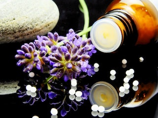

[Photo by Pixabay from Pexels](https://www.pexels.com/photo/green-purple-flower-163186/)

## Mediaton paths

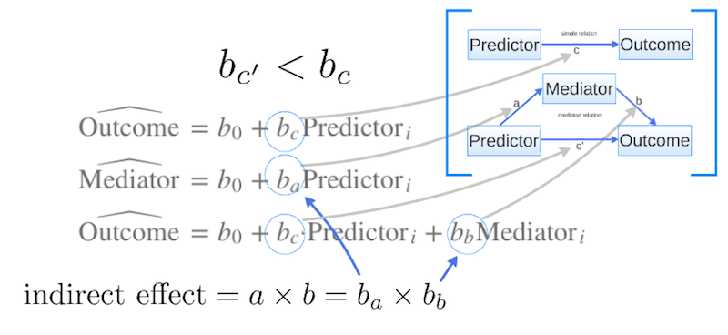

Mediation Path

## Simulate data

Create predictor variable

```r
set.seed(1976)
## Set parameters for simulation
n     = 100
mu    = 10
sigma = 2
## Predictor
use.homeopathic.remedies = rnorm(n, mu, sigma)
```

## Mediator

Create mediator

```r
b0    = 2
b1    = 1.2
error = rnorm(n,0,.7)
healthy.lifestyle = b0 + b1*use.homeopathic.remedies + error
```

## Specify model

Create outcome variable

```r
b0    = 6
b1    = 1.2
b2    = 3
error = rnorm(n,0,1.4)
speed.of.healing = b0 + b1*use.homeopathic.remedies + b2*healthy.lifestyle + error

data <- data.frame(use.homeopathic.remedies,
                   healthy.lifestyle,
                   speed.of.healing)
data <- round(data, 4)
```

## The data

| use.homeopathic.remedies | healthy.lifestyle | speed.of.healing |
| --- | --- | --- |
| 11.8474 | 16.3304 | 69.3519 |
| 6.4263 | 10.4394 | 44.9527 |
| 7.4717 | 11.7643 | 50.7425 |
| 11.1266 | 15.3475 | 68.1927 |
| 9.86 | 14.5618 | 63.0681 |
| 10.2019 | 14.626 | 61.0033 |
| 8.0348 | 11.9731 | 52.0447 |
| 8.9638 | 12.6817 | 54.3619 |
| 7.5647 | 10.485 | 48.1224 |
| 12.8471 | 17.045 | 72.3886 |

[output cut: 90 more lines]

## Apply 3 models

```r
m.1.out.pre     <- lm(speed.of.healing ~ use.homeopathic.remedies)
m.2.med.pre     <- lm(healthy.lifestyle ~ use.homeopathic.remedies)
m.3.out.pre.med <- lm(speed.of.healing ~ use.homeopathic.remedies + healthy.lifestyle)
```

## Extract beta coëfficients

```r
b.a        = m.2.med.pre$coefficients[2]
b.b        = m.3.out.pre.med$coefficients[3]
b.c        = m.1.out.pre$coefficients[2]
b.c.accent = m.3.out.pre.med$coefficients[2]
```

## View beta coëfficients

```r
b.a
```

```
## use.homeopathic.remedies
##                 1.210308
```

```r
b.b
```

```
## healthy.lifestyle
##          2.859761
```

## View beta coëfficients

```r
b.c
```

```
## use.homeopathic.remedies
##                 4.762102
```

```r
b.c.accent
```

```
## use.homeopathic.remedies
##                  1.30091
```

## Visual

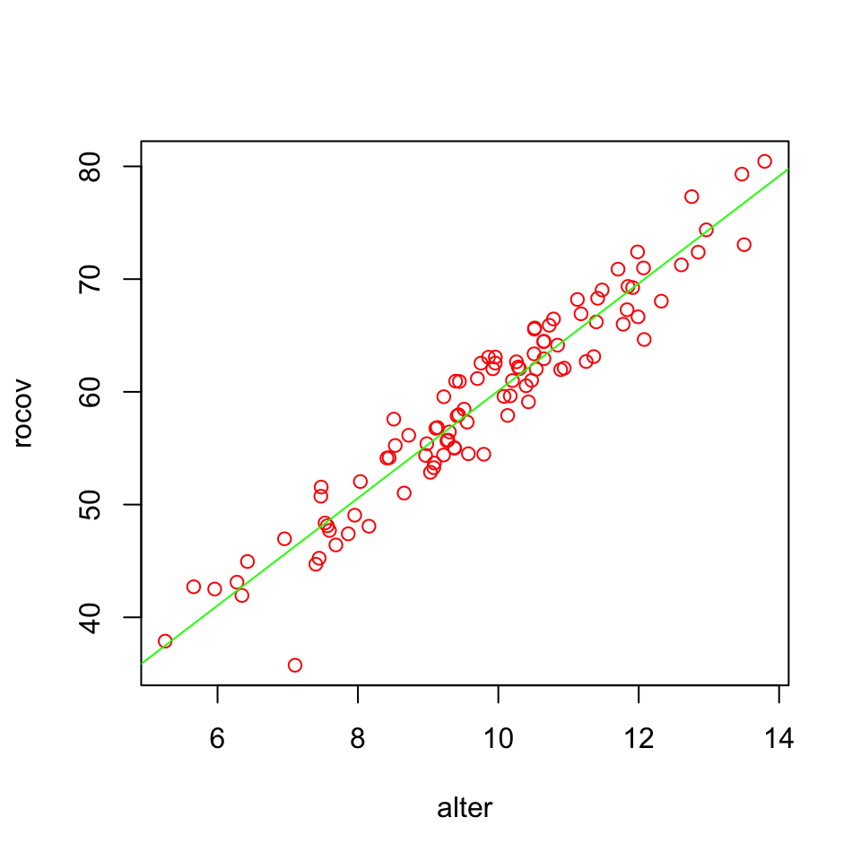

```r
plot(data$use.homeopathic.remedies, data$speed.of.healing, col = 'red', xlab="alter", ylab="rocov")

fit.1 <- lm(speed.of.healing ~ use.homeopathic.remedies, data)

abline(fit.1, col = 'green')
```

## 3D Visual

[interactive chart not shown]

Interactive, give it a spin.

## Calculate indirect effect

\[a \times b = b_a \times b_b\]

```r
b.a*b.b
```

```
## use.homeopathic.remedies
##                 3.461192
```

```r
b.c - b.c.accent
```

```
## use.homeopathic.remedies
##                 3.461192
```

## Calculate indirect effect (partially standardized)

\[\frac{ab}{s_{Outcome}} = \frac{b_a b_b}{s_{Outcome}}\]

```r
b.a*b.b/sd(speed.of.healing)
```

```
## use.homeopathic.remedies
##                0.3833868
```

## Calculate indirect effect (standardized)

\[\frac{ab}{s_{Outcome}} \times s_{Predictor} = \frac{b_a b_b}{s_{Outcome}} \times s_{Predictor}\]

```r
b.a*b.b/sd(speed.of.healing)*sd(use.homeopathic.remedies)
```

```
## use.homeopathic.remedies
##                0.6979258
```

## Calculate \(P_M\)

\[\frac{ab}{c} = \frac{b_a b_b}{b_c}\]

```r
b.a*b.b/b.c
```

```
## use.homeopathic.remedies
##                0.7268202
```

## Calculate \(R_M\)

\[\frac{ab}{c`} = \frac{b_a b_b}{b_{c`}}\]

```r
b.a*b.b/b.c.accent
```

```
## use.homeopathic.remedies
##                 2.660593
```

## Calculate \(R^2_M\)

\[R^2_{out,med} − (R^2_{out,pre \times med} − R^2_{out,pre})\]

```r
m.4.out.med <- lm(speed.of.healing ~ healthy.lifestyle)
R2_out.med     = cor(m.4.out.med$fitted.values, speed.of.healing)^2
R2_out.pre.med = cor(m.3.out.pre.med$fitted.values, speed.of.healing)^2
R2_out.pre     = cor(m.1.out.pre$fitted.values, speed.of.healing)^2

R2_out.med - (R2_out.pre.med - R2_out.pre)
```

```
## [1] 0.9161054
```

## Calculate \(\kappa^2\)

PROCESS version 2.16 no longer produces Preacher and Kelley’s kappa- squared as a measure of effect size for the indirect effect. This feature in earlier releases was disabled in version 2.16 in response to a recent article by Wen and Fan (2015, Psychological Methods) pointing out computational errors in its derivation.

\[\frac{ab}{max(ab)} = \frac{b_a b_b}{max(b_a b_b)}\]

What is \(max(ab)\)?

## End

- [@shklinkenberg](https://twitter.com/shklinkenberg)
- [Klinkenberg](https://www.linkedin.com/in/sharonklinkenberg/)
- ln.AvU@grebneknilK.S
- ShKlinkenberg